# Kickstarter Data

## Columns Explanation

1. ID = internal kickstarter id
2. name = name of project - A project is a finite work with a clear goal that you’d like to bring to life. Think albums, books, or films.
3. category = category
4. main_category = category of campaign
5. currency = currency used to support
6. deadline = deadline for crowdfunding
7. goal = fundraising goal - The funding goal is the amount of money that a creator needs to complete their project.
8. launched = launched date launched
9. pledged = amount pledged by “crowd”
10. state = Current condition the project is in
11. backers = number of backers
12. country = country pledged from
13. usd pledged = amount of money pledged

## Packages Needed to Download

```r
#install.packages("ggplot2")
library(ggplot2)
library(doBy)
#install.packages("useful")
library(useful)
library(glmnet)
#install.packages('rpart')
library(rpart)
#install.packages("randomForest")
library("randomForest")
set.seed(1861)
```

```r
#reads in data into KickStar
KickStar <- read.csv("/Users/Cheddar3/Desktop/MGSC310/Group Projects/kickstarter-projects/ks-projects-201612.csv")
#removing a few columns with null values
KickStar <- subset(KickStar, select = -c(14,15,16,17))
#colSums(is.na(KickStar))
KickStar<- KickStar[!is.na(KickStar$name),]
#colSums(is.na(KickStar))
#cleaning up category column
KickStar$category <- factor(KickStar$category, levels = c("Zines","Young Adult", "World Music", "Workshops" ,"Woodworking", "Webseries", "Webcomics", "Web","Weaving", "Wearables", "Video Games", "Video Art", "Video", "Vegan", "Typography", "Translations", "Thrillers", "Theater", "Textiles", "Television", "Technology", "Taxidermy", "Tabletop Games", "Stationery", "Spaces", "Space Exploration", "Sound", "Software", "Small Batch", "Shorts", "Sculpture", "Science Fiction", "Romance", "Rock", "Robots", "Restaurants", "Residencies", "Ready-to-wear", "Radio & Podcasts", "R&B", "Quilts", "Puzzles", "Punk", "Publishing", "Public Art", "Product Design", "Printing", "Print", "Pottery", "Pop", "Poetry", "Plays", "Playing Cards", "Places", "Photography", "Photobooks", "Photo", "Pet Fashion", "Periodicals", "Performances", "Performance Art", "People", "Painting", "Nonfiction", "Nature", "Narrative Film", "Musical", "Music Videos", "Music", "Movie Theaters", "Mobile Games", "Mixed Media", "Metal", "Makerspaces", "Live Games", "Literary Journals", "Letterpress", "Latin", "Knitting", "Kids", "Journalism", "Jewelry", "Jazz", "Interactive Design", "Installations", "Indie Rock", "Immersive", "Illustration", "Horror", "Hip-Hop", "Hardware", "Graphic Novels", "Graphic Design", "Glass", "Gaming Hardware", "Games", "Gadgets", "Footwear", "Food Trucks", "Food", "Flight", "Fine Art", "Film & Video", "Fiction", "Festivals", "Fashion", "Farms", "Farmer's Markets", "Fantasy", "Family", "Faith", "Fabrication Tools", "Experimental", "Events", "Embroidery", "Electronic Music", "Drinks", "Drama", "Documentary", "DIY Electronics", "DIY", "Digital Art", "Design", "Dance", "Crochet", "Crafts", "Couture", "Country & Folk", "Cookbooks", "Conceptual Art", "Community Gardens", "Comics", "Comic Books", "Comedy", "Classical Music", "Civic Design", "Chiptune", "Childrenswear", "Children's Books", "Ceramics", "Candles", "Camera Equipment", "Calendars", "Blues", "Bacon", "Audio", "Art Books", "Art", "Architecture", "Apps", "Apparel", "Anthologies", "Animation", "Animals", "Action", "Accessories", "Academic", "3D Printing"))
#colSums(is.na(KickStar))
KickStar<- KickStar[!is.na(KickStar$category),]
#colSums(is.na(KickStar))
#cleaning main_category column
#table(KickStar$main_category)
KickStar$main_category <- factor(KickStar$main_category, levels = c("Theater", "Technology", "Publishing", "Photography", "Music", "Journalism", "Games", "Food", "Film & Video", "Fashion", "Design", "Dance", "Crafts", "Comics", "Art"))
#colSums(is.na(KickStar))
#clearning currency column
#table(KickStar$currency)
KickStar$currency <- factor(KickStar$currency, levels = c("USD", "SGD", "SEK", "NZD", "NOK", "MXN", "HKD", "GBP", "EUR", "DKK", "CHF", "CAD", "AUD"))
#colSums(is.na(KickStar))
#cleaning goal column
KickStar$goal <- as.numeric(KickStar$goal)
#colSums(is.na(KickStar))
#cleaning pledge column
KickStar$pledged <- as.numeric(KickStar$pledged)
#cleaning state column
#table(KickStar$state)
KickStar$state <- factor(KickStar$state, levels = c("failed", "successful"))
#colSums(is.na(KickStar))
KickStar<- KickStar[!is.na(KickStar$state),]
#colSums(is.na(KickStar))
#cleaning backers column
KickStar$backers <- as.numeric(KickStar$backers)
#colSums(is.na(KickStar))
#cleaning country column
#table(KickStar$country)
KickStar$country <- factor(KickStar$country, levels = c("US", "SG", "SE", "NZ", "NO", "NL", "MX", "LU", "IT", "IE", "HK", "GB", "FR", "ES", "DK", "DE", "CH", "CA", "BE", "AU", "AT"))
#colSums(is.na(KickStar))
KickStar<- KickStar[!is.na(KickStar$country),]
#colSums(is.na(KickStar))
#cleaning usd.pledged column
KickStar$usd.pledged <- as.numeric(KickStar$usd.pledged)
#colSums(is.na(KickStar))
#creates deadline and launched variable so its just year/month/day
KickStar$newDeadline <- as.Date(as.POSIXlt(KickStar$deadline, origin = "1582-10-14",tz = "GMT"))
KickStar$newLaunched <- as.Date(as.POSIXlt(KickStar$launched, origin = "1582-10-14",tz = "GMT"))
#difference between launched and deadline in days
KickStar$DateDiffDays <- KickStar$newDeadline - KickStar$newLaunched
#if successful, then 1, else 0
KickStar$binomState <- ifelse(KickStar$state == "successful",1,0)
trainSize <- 0.75
trainInd <- sample(1:nrow(KickStar), size = floor(nrow(KickStar) * trainSize))
KickTrain <- KickStar[trainInd, ]
KickTest <- KickStar[-trainInd, ]
#gets summary of data
summary(KickStar)
```

```
##        ID                                    name
##  Min.   :5.971e+03   New EP/Music Development  :    13
##  1st Qu.:5.373e+08   New EP / Music Development:    10
##  Median :1.076e+09   Music Video               :     9
##  Mean   :1.075e+09   Reflections               :     9
##  3rd Qu.:1.611e+09   A Midsummer Night's Dream :     8
##  Max.   :2.147e+09   Pizza                     :     8
##                      (Other)                   :281034
##            category           main_category      currency
##  Product Design: 14515   Film & Video:51034   USD    :229365
##  Documentary   : 13346   Music       :40808   GBP    : 23820
##  Shorts        : 10775   Publishing  :30143   CAD    :  9899
##  Music         : 10724   Games       :22398   EUR    :  9156
##  Food          :  9517   Art         :21745   AUD    :  5183
##  Tabletop Games:  8819   Technology  :21405   SEK    :  1065
##  (Other)       :213395   (Other)     :93558   (Other):  2603
##                 deadline           goal                     launched
##  2012-01-01 05:59:00:    46   Min.   :   1   2009-09-15 05:56:28:     2
##  2014-11-01 04:59:00:    34   1st Qu.:1257   2010-06-30 17:29:43:     2
##  2015-01-01 05:59:00:    34   Median :4145   2011-02-08 04:29:48:     2
##  2012-03-01 05:59:00:    32   Mean   :3693   2011-02-25 09:58:36:     2
##  2010-08-01 05:59:00:    28   3rd Qu.:5820   2011-03-07 17:11:18:     2
##  2010-09-01 05:59:00:    28   Max.   :8181   2011-06-07 06:42:01:     2
##  (Other)            :280889                  (Other)            :281079
##     pledged             state           backers        country
##  Min.   :    1   failed    :168115   Min.   :   1   US     :229365
##  1st Qu.: 5597   successful:112976   1st Qu.: 156   GB     : 23820
##  Median :23388                       Median :1395   CA     :  9899
##  Mean   :23310                       Mean   :1465   AU     :  5183
##  3rd Qu.:39532                       3rd Qu.:2537   DE     :  2130
##  Max.   :55597                       Max.   :3587   NL     :  1869
##                                                     (Other):  8825
##   usd.pledged     newDeadline          newLaunched
##  Min.   :    2   Min.   :2009-05-03   Min.   :2009-04-21
##  1st Qu.: 9838   1st Qu.:2012-12-26   1st Qu.:2012-11-22
##  Median :39322   Median :2014-08-11   Median :2014-07-11
##  Mean   :39382   Mean   :2014-04-13   Mean   :2014-03-10
##  3rd Qu.:66703   3rd Qu.:2015-08-07   3rd Qu.:2015-07-05
##  Max.   :94361   Max.   :2016-12-06   Max.   :2016-12-01
##
##  DateDiffDays        binomState
##  Length:281091     Min.   :0.0000
##  Class :difftime   1st Qu.:0.0000
##  Mode  :numeric    Median :0.0000
##                    Mean   :0.4019
##                    3rd Qu.:1.0000
##                    Max.   :1.0000
##
```

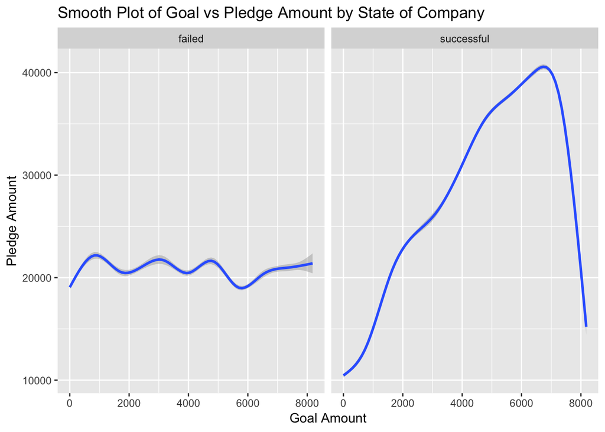

```r
#ggplot of Goal Amount and Pledge Amount by state of company
ggplot(data = KickStar, aes(goal, pledged)) + geom_smooth() + facet_wrap(~state) + labs(title = "Smooth Plot of Goal vs Pledge Amount by State of Company") + labs(x = "Goal Amount", y = "Pledge Amount")
```

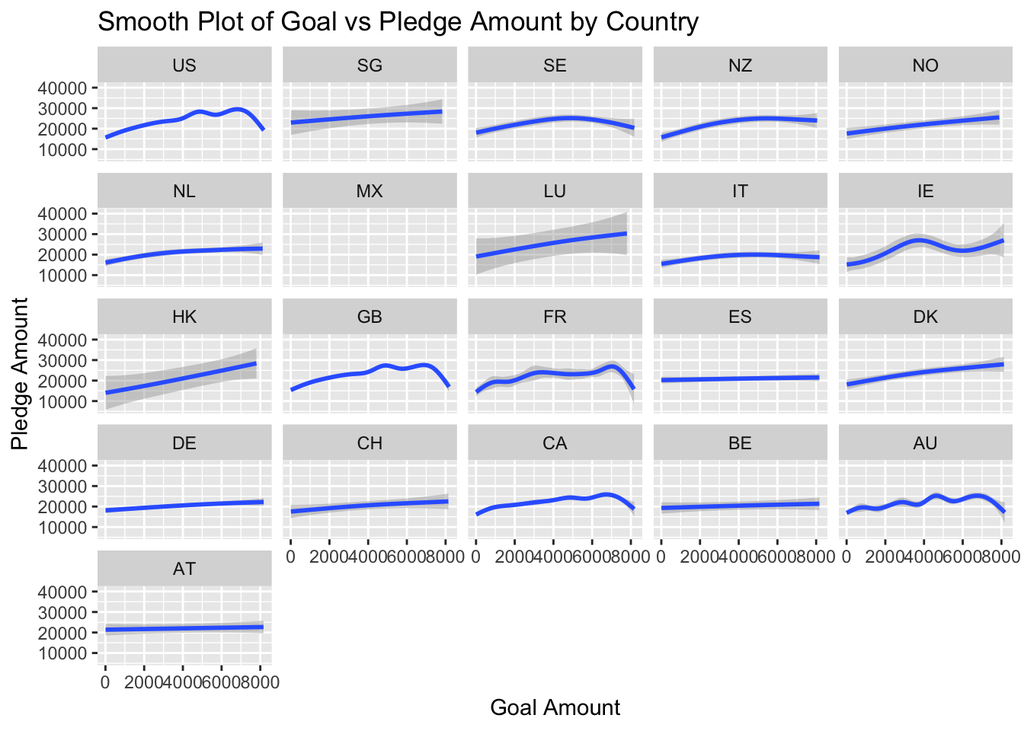

```r
#ggplot of Goal Amount and Pledge Aamount by country
ggplot(data = KickStar, aes(goal, pledged)) + geom_smooth() + facet_wrap(~country) + labs(title = "Smooth Plot of Goal vs Pledge Amount by Country") + labs(x = "Goal Amount", y = "Pledge Amount")
```

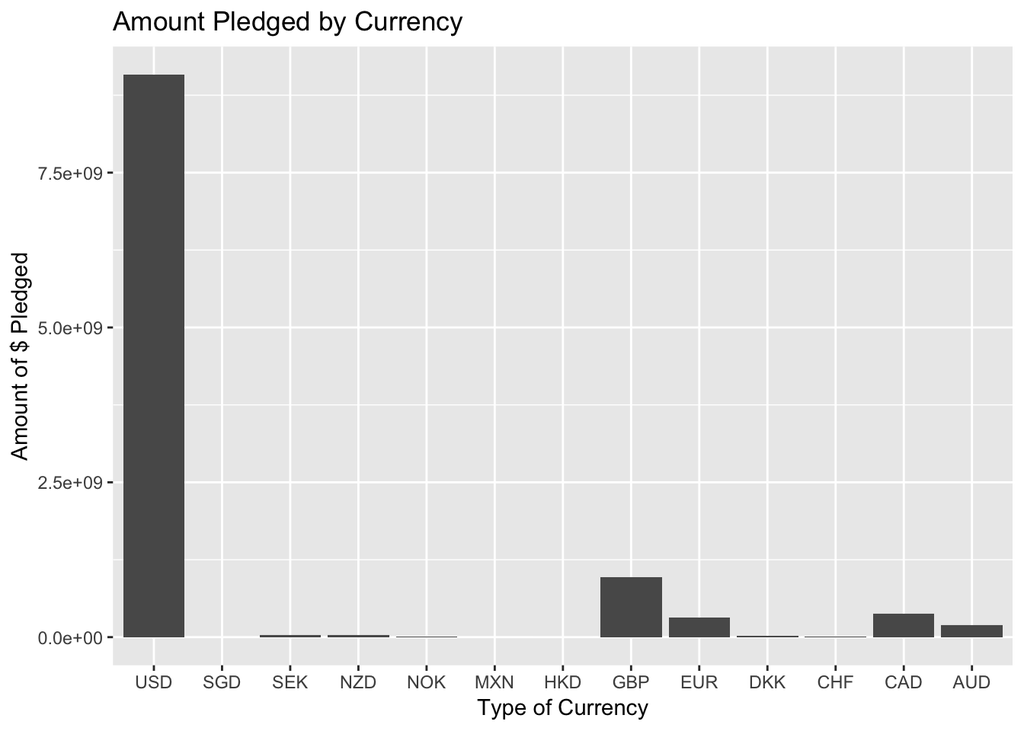

```r
#ggplot of bar graph with type of currency and the amount pledged
ggplot(data = KickStar, aes(x = currency, y = usd.pledged)) + geom_bar(stat = "identity") + labs(x = "Type of Currency", y = "Amount of $ Pledged") + labs(title = "Amount Pledged by Currency")
```

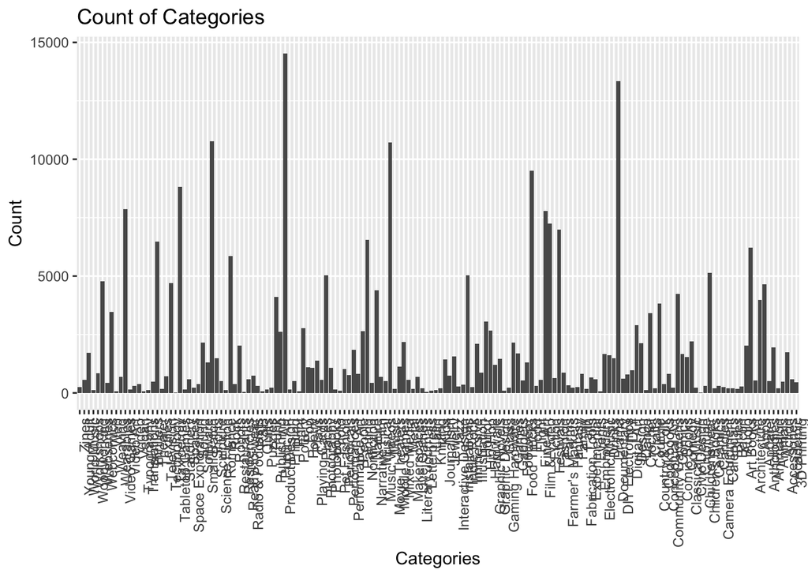

```r
##ggplot of bar graph of count of each categories
ggplot(data = KickStar, aes(category)) + geom_bar() + theme(axis.text.x = element_text(angle = 90, hjust = 1)) + labs(title = "Count of Categories", x = "Categories", y = "Count")
```

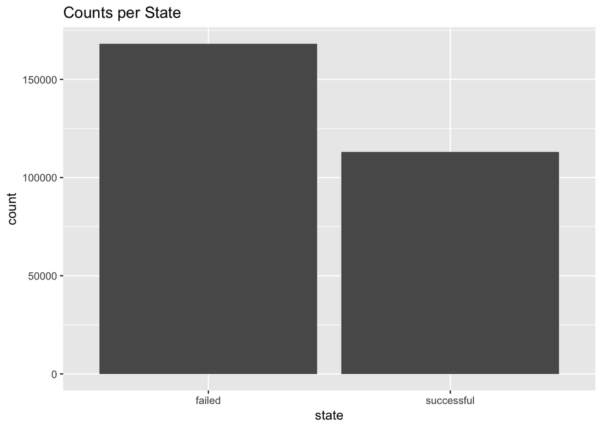

```r
#ggplot of bar graph of count by state
ggplot(data = KickStar, aes(state)) + geom_bar() + labs(title = "Counts per State")
```